# SCW17/Paper-01a Far North model selectivity

Published

June 14, 2026

Rendered 14 June 2026, 23:32 CEST

# 1 Purpose

This diagnostic follows up on [items 11 and 12 in the SCW16 benchmark meeting report](https://sprfmo.github.io/JM_SCW_prep/JMWG-Benchmark-Meeting-report-2026.html#decisions-and-agreements), which identified the need to test variable Peru fishery selectivity for catch length-frequency data and to link Peru survey length frequencies to survey selectivity estimation.

Table 1: FN run configurations read from the active assessment outputs.

| model | label | msy_sel_argument | data_file | stocks | fisheries | fishery_names | indices | index_names | fishery_age_comp_years | fishery_length_comp_years | end_year | n_parameters | nll | max_gradient |
| --- | --- | --- | --- | --- | --- | --- | --- | --- | --- | --- | --- | --- | --- | --- |
| FN | FN base | default | FN.dat | 1 | 1 | FarNorth | 2 | Peru_Artis, Peru_Ind | 0 | 54 | 2025 | 618 | 629.4314 | 1e-04 |
| FN_selblocks | FN selectivity blocks | default | FN.dat | 1 | 1 | FarNorth | 2 | Peru_Artis, Peru_Ind | 0 | 54 | 2025 | 177 | 549.7744 | 6e-05 |

# 2 Fitted Model Comparisons

The diagnostics in this section compare the model predictions from the rerun `FN` and `FN_selblocks` fits.

Table 2: Transposed fitted-model comparison for FN and FN_selblocks. NLL components are read from the reported likelihood-component block; SDNR values are computed from the reported standardized residuals for each Peruvian CPUE index.

| Metric | FN base | FN selectivity blocks |
| --- | --- | --- |
| Estimated parameters | 618.00000 | 177.00000 |
| Total NLL | 629.43142 | 549.77436 |
| Delta total NLL | 79.65705 | 0.00000 |
| Catch biomass NLL | 0.29848 | 0.06038 |
| Fishery age-composition NLL | 0.00000 | 0.00000 |
| Fishery length-frequency NLL | 471.70400 | 475.97700 |
| Index NLL | 14.64230 | 18.12590 |
| Survey age-composition NLL | 0.00000 | 0.00000 |
| Survey length-frequency NLL | 0.00000 | 0.00000 |
| Fishery selectivity penalty | 113.95400 | 54.46570 |
| Survey selectivity penalty | 0.00000 | 0.00000 |
| Recruitment penalty | 28.25130 | 0.99292 |
| F penalty | 0.15466 | 0.07689 |
| Index q prior penalty | 0.01086 | 0.06125 |
| Other prior penalty | 0.00000 | 0.00000 |
| Residual | 0.41512 | 0.01392 |
| Maximum gradient | 0.00010 | 0.00006 |
| Mean index SDNR | 0.78818 | 0.89311 |
| Peru Artis SDNR | 0.67459 | 0.86040 |
| Peru Ind SDNR | 0.90178 | 0.92581 |

The selectivity-block model has a lower total negative log-likelihood than the base run, but Table 2 shows that the reduction comes mainly from lower FarNorth fishery-selectivity and recruitment penalties. The direct length-frequency and index likelihood components are higher for `FN_selblocks`, and mean CPUE-index SDNR also increases. The result is therefore useful as a diagnostic of how selectivity flexibility changes the fitted dynamics, but it does not by itself indicate a clear improvement in the data fits used for advice.

## 2.1 Selectivity Time Series

The ridge plots compare the fitted FarNorth fishery selectivity-at-age trajectories from the base `FN` and `FN_selblocks` runs. The selectivity-block run uses change years in 1980, 1999, 2010, and 2020. Ages are plotted as actual model ages 1-12.

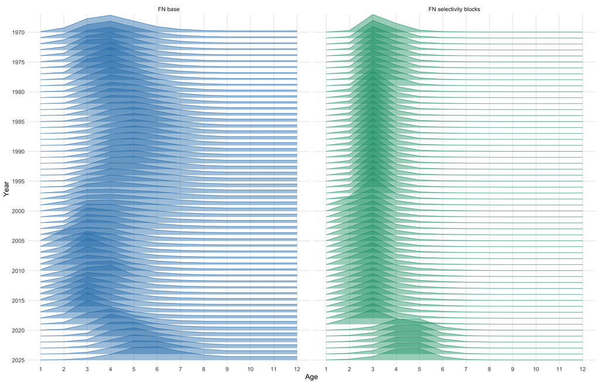

Figure 1: FN FarNorth fishery selectivity-at-age time series for the base and selectivity-block runs. Ages are shown from 1 to 12.

The base run estimates a smoother progression in FarNorth selectivity through time, whereas `FN_selblocks` concentrates most years around a narrower age-3 peak and then shifts the most recent block toward older ages (Figure 1). The change is important because the lower total NLL in Table 2 is associated mostly with the selectivity-penalty structure rather than with improved catch-at-length or CPUE likelihood components.

## 2.2 Catch Biomass

The catch biomass panel compares the observed FarNorth catch biomass from the active data file with the fitted catch biomass from the `FN` and `FN_selblocks` runs.

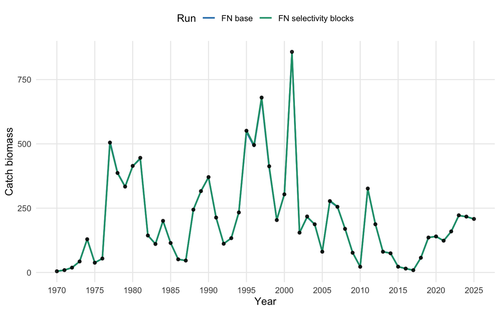

Figure 2: Observed and predicted FarNorth catch biomass by year for the FN and FN_selblocks runs.

Both model configurations reproduce the annual FarNorth catch biomass almost identically in Figure 2. This visual result is consistent with the small catch-biomass likelihood contribution in Table 2, indicating that the selectivity-block configuration does not materially change the catch-biomass fit.

## 2.3 Index Fits

Points and vertical intervals show the observed Peruvian CPUE values and nominal 95% intervals from the active data file. Lines show the fitted values from the `FN` and `FN_selblocks` runs.

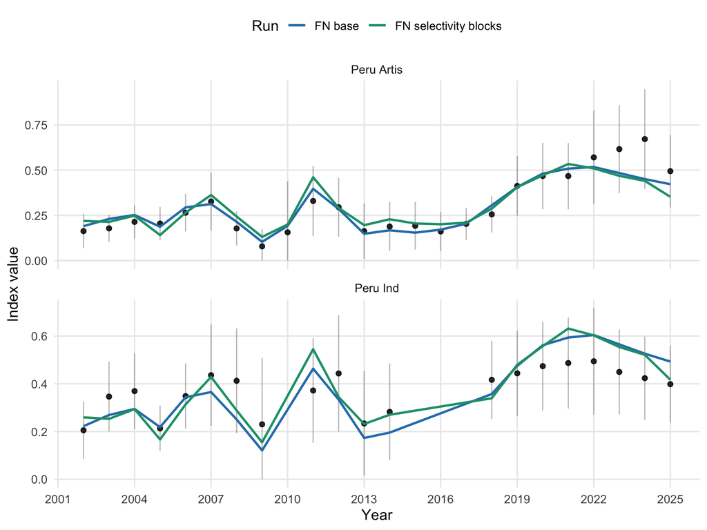

Figure 3: FN and FN_selblocks fits to the Peruvian artisanal and industrial CPUE indices.

The CPUE fits are broadly similar for both runs, but `FN_selblocks` tends to be slightly higher than the base run in several early and mid-series years (Figure 3). The index likelihood and both index-specific SDNR values are higher for `FN_selblocks` in Table 2, so the added selectivity blocks do not improve the Peruvian CPUE fit.

## 2.4 Catch-At-Length Fits

The FarNorth catch-at-length panels show observed length proportions as bars or black points and fitted proportions from the `FN` and `FN_selblocks` runs.

**Aggregate By Period**

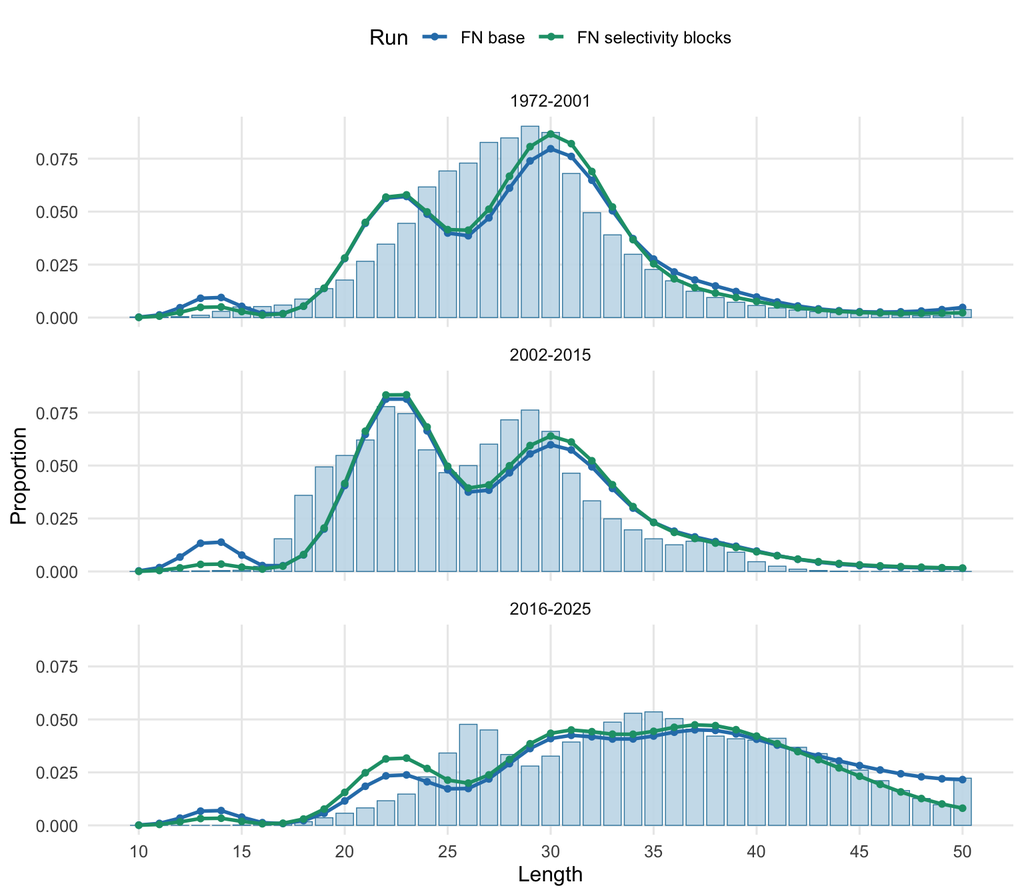

Figure 4: Sample-size-weighted aggregate FarNorth catch-at-length fits for the FN and FN_selblocks runs.

**Recent Years**

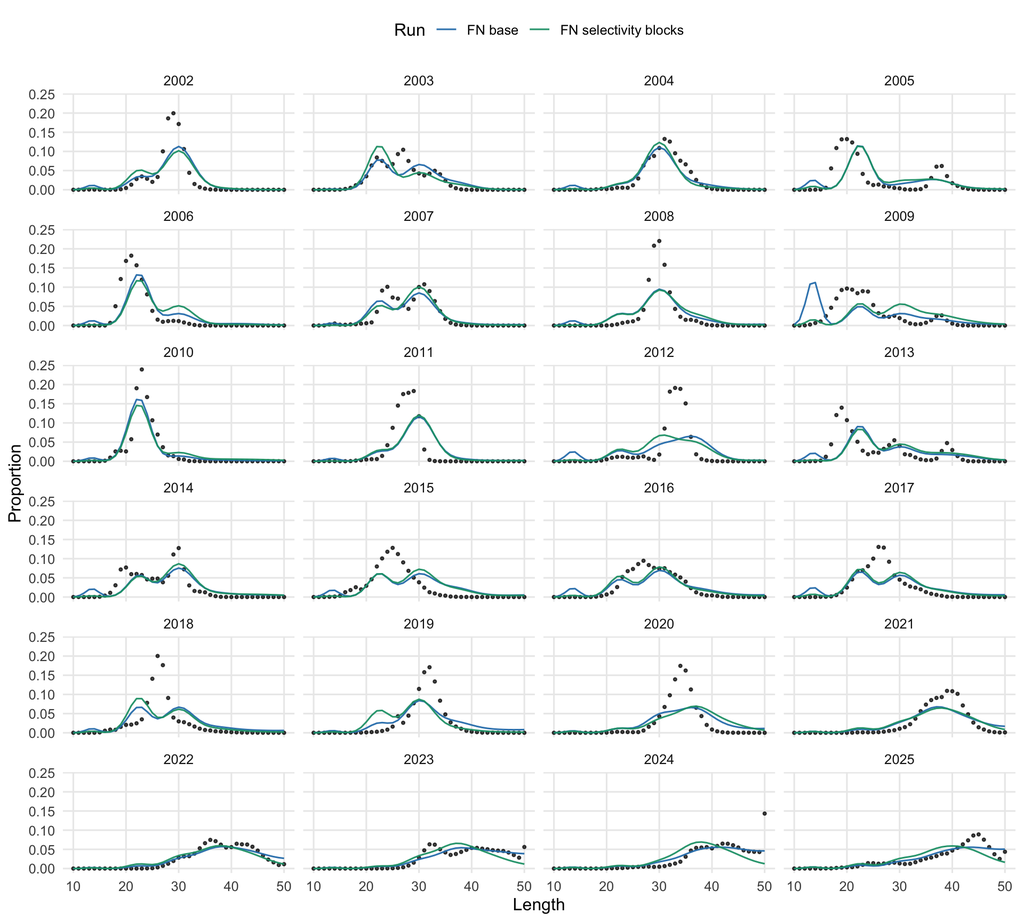

Figure 5: Recent annual FarNorth catch-at-length fits for the FN and FN_selblocks runs.

**All Years**

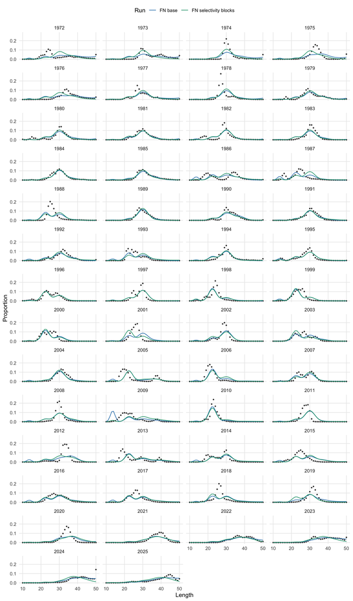

Figure 6: All annual FarNorth catch-at-length fits for the FN and FN_selblocks runs.

The aggregate and annual length-frequency panels show modest differences between the two runs, especially around the lower-length modes in the 2002-2015 and 2016-2025 periods (Figure 4, Figure 5, and Figure 6). However, the fishery length-frequency NLL is slightly higher for `FN_selblocks` in Table 2, so the extra selectivity flexibility should not be interpreted as improving the length-composition fit overall.

# 3 Conclusion

The most flexible selectivity model provides only limited improvement in fitting the length-frequency data relative to the base `FN` configuration. Based on these diagnostics, we propose using a more static selectivity set that is allowed to change during apparent availability-at-size shifts over time, rather than relying on highly flexible selectivity blocks to absorb the length-frequency patterns.